# inferCNV分析报告

杭州广科安德生物科技有限公司

# 1 inferCNV

## 1.1 目的

inferCNV用于推断细胞的染色体拷贝数变异（CNV）情况，是目前单细胞数据鉴定恶性细胞的最经典常用的工具。

拷贝数变异（CNV）：指特定 DNA 片段的拷贝数量在不同个体基因组中有所不同。这些结构差异可能是通过重复、缺失或其他变化产生的，可能影响长段的 DNA。CNV变异是肿瘤细胞最显著的特征。

## 1.2 CNV强度热图

热图展示了不同细胞在各染色体区域的相对表达强度。图中每一行代表所属亚群的一个细胞，每一列表示对应染色体上的一个基因。红色代表扩增，蓝色代表缺失，颜色越深代表变异越显著。

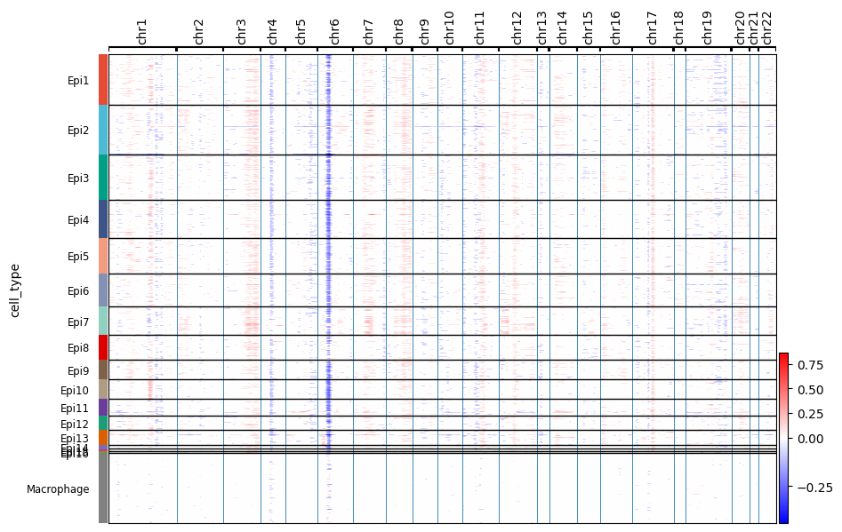

## 1.3 转录组聚类UMAP图

该图基于转录组数据的umap图，左图不同颜色代表不同的CNV聚类；中图不同颜色代表不同细胞类型；右图展示了各细胞的CNV分数，颜色越亮，CNV分数越高，恶性越强。

### 1.3.1 by cell

对每一个细胞进行CNV评分。

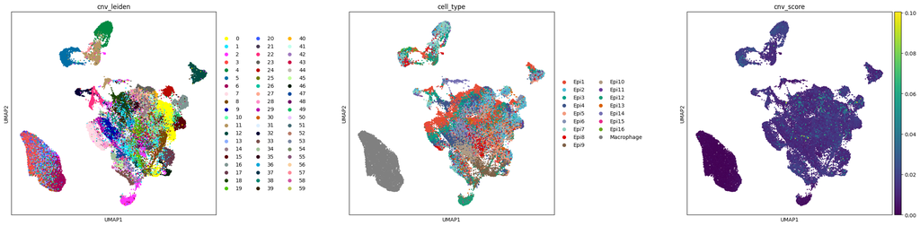

<sub>注 **左:** CNV cluster；中**:** cell type；**右:** CNV score；</sub>

### 1.3.2 by cluster

对每一个CNV聚类进行CNV评分。

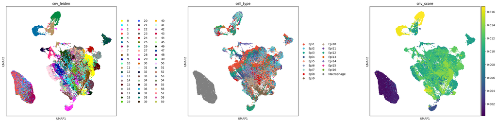

<sub>注 **左:** CNV cluster；中**:** cell type；**右:** CNV score；</sub>

## 1.4 CNV聚类UMAP图

该图基于CNV分析的umap图，左图不同颜色代表不同的CNV聚类；中图不同颜色代表不同细胞类型；右图展示了各细胞的CNV分数，颜色越亮，CNV分数越高，恶性越强。

### 1.4.1 by cell

对每一个细胞进行CNV评分。

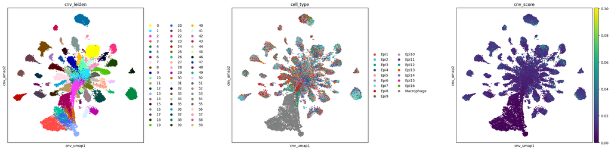

<sub>注 **左:** CNV cluster；中**:** cell type；**右:** CNV score；</sub>

### 1.4.2 by cluster

对每一个CNV聚类进行CNV评分。

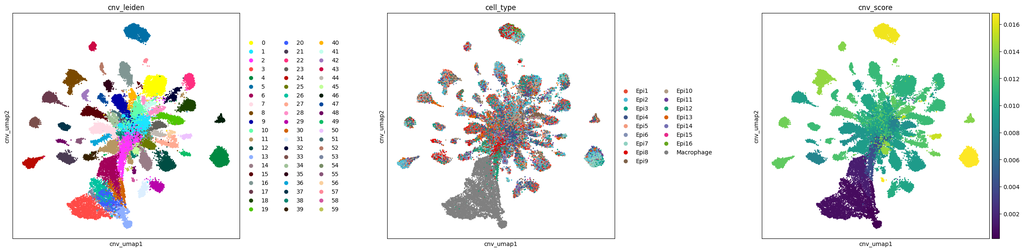

<sub>注 **左:** CNV cluster；中**:** cell type；**右:** CNV score；</sub>

## 1.5 CNV聚类提琴图

横轴代表不同的CNV cluster，纵轴代表细胞的CNV分数，每一个点代表一个细胞。通过对比不同cluster的CNV分数差异筛选出其中恶性的cluster。

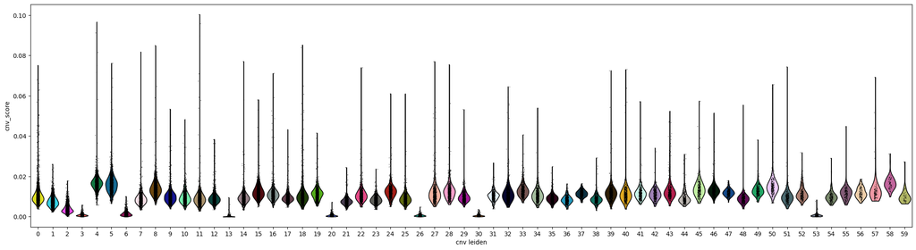

<sub>注 **横轴:** CNV cluster；**纵轴:** CNV score；</sub>

## 1.6 CNV注释UMAP图

根据CNV分数对细胞进行注释，橙色为恶性细胞，蓝色为正常细胞。

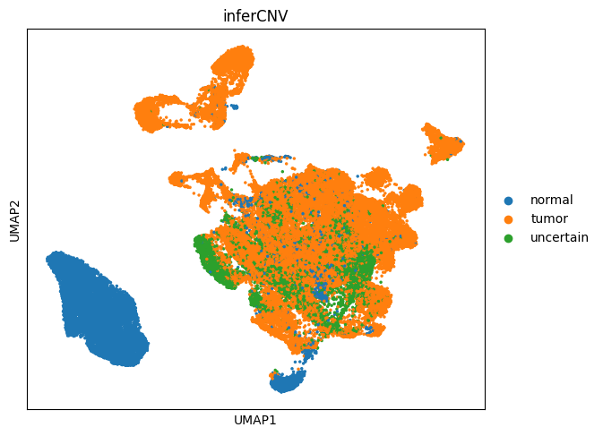

## 1.7 CNV分数表格

不同细胞的CNV聚类与CNV分数。

|  | barcode | cell_type | cnv_leiden | cnv_score_cell | cnv_score_cluster | inferCNV |
| --- | --- | --- | --- | --- | --- | --- |
| 1 | GSE160269_P32T.I.GTAACGTTCCCAAGTA | Macrophage | 3 | 0.0013065579761813 | 0.000786694477311 | normal |
| 2 | GSE160269_P26T.E.GATCAGTGTTCCACTC | Epi1 | 16 | 0.0104579493401377 | 0.0113888813471879 | tumor |
| 3 | GSE160269_P127T.E.AGCGTATGTGGACGAT | Epi11 | 8 | 0.0096543856739953 | 0.0141003281947574 | uncertain |
| 4 | GSE160269_P31T.E.CAACCAAAGGCCGAAT | Epi11 | 12 | 0.0090267957041068 | 0.0092440212535666 | tumor |
| 5 | GSE160269_P42T.E.TTGAACGTCGTAGATC | Epi10 | 1 | 0.0050638310472085 | 0.0075270086257983 | uncertain |
| 6 | GSE160269_P37T.E.TTAGGCACATAGGATA | Epi3 | 38 | 0.0059752053035589 | 0.0088182530205365 | tumor |
| 7 | GSE160269_P62T.E.ATGCGATCATTAGGCT | Epi5 | 21 | 0.0091284480203726 | 0.00770201130168 | tumor |
| 8 | GSE160269_P15T.E.ATGAGGGCAAGTCATC | Epi4 | 27 | 0.0067040091201283 | 0.0122070743506049 | tumor |
| 9 | GSE160269_P20T.E.GACAGAGTCACTGGGC | Epi8 | 43 | 0.0087372674441855 | 0.013710882629284 | tumor |
| 10 | GSE160269_P21T.E.GGATTACGTACACCGC | Epi11 | 39 | 0.0105167694351315 | 0.0120728241011853 | tumor |

[output cut: 51561 more lines]